# Assignment_08

### Download and unzip the dataset

```python
!wget -nc http://vis-www.cs.umass.edu/lfw/lfw.tgz
!tar --skip-old-files -zxf  lfw.tgz
```

```
File ‘lfw.tgz’ already there; not retrieving.
```

```python
import os
import torch
import torch.nn as nn
from tqdm.notebook import tqdm
import numpy as np
import matplotlib.pyplot as plt
plt.style.use('seaborn')
from torchvision import datasets, transforms, models
```

### Preprocessing and splitting the dataset

```python
mean = np.array([0.485, 0.456, 0.406])
std = np.array([0.229, 0.224, 0.225])

transform = transforms.Compose([
    transforms.ToTensor(),
    transforms.Normalize(mean, std)
])

dataset = datasets.ImageFolder('lfw', transform=transform)
train_size, val_size = int(0.7*len(dataset)), int(0.2*len(dataset))
test_size = len(dataset) - train_size - val_size
train_ds, val_ds, test_ds = torch.utils.data.random_split(dataset, [train_size, val_size, test_size])
```

```python
class TripletDataset:
    def __init__(self, dataset):
        self.dataset = dataset
        self.labels = np.array([l for _,l in dataset])

    def __len__(self):
        return len(self.dataset)

    def __getitem__(self, i):
        anchor_img, anchor_lbl = self.dataset[i]

        pos_ids = np.flatnonzero(self.labels == anchor_lbl)
        neg_ids = np.flatnonzero(self.labels != anchor_lbl)

        pos_id = np.random.choice(pos_ids, 1).item()
        neg_id = np.random.choice(neg_ids, 1).item()

        pos_img, pos_lbl = self.dataset[pos_id]
        neg_img, neg_lbl = self.dataset[neg_id]

        return (anchor_img, pos_img, neg_img), (anchor_lbl, pos_lbl, neg_lbl)
```

```python
train_triplet_ds = TripletDataset(train_ds)
val_triplet_ds = TripletDataset(val_ds)
test_triplet_ds = TripletDataset(test_ds)
```

```python
train_loader = torch.utils.data.DataLoader(dataset=train_triplet_ds, batch_size=64, shuffle=True)
val_loader = torch.utils.data.DataLoader(dataset=val_triplet_ds, batch_size=64, shuffle=True)
test_loader = torch.utils.data.DataLoader(dataset=test_triplet_ds, batch_size=64, shuffle=False)
```

```python
device = torch.device("cuda" if torch.cuda.is_available() else "cpu")
```

### Visualizing the dataset

```python
def unnormalize(img):
    img = img.permute(1, 2, 0) * std + mean
    img = img.clip(0, 1)
    return img
```

[figure not shown]

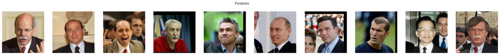

[figure not shown]

```python
fig_anchors, anchors = plt.subplots(1, 10, figsize=(30,3))
fig_pos, positives = plt.subplots(1, 10, figsize=(30,3))
fig_neg, negatives = plt.subplots(1, 10, figsize=(30,3))
for i in range(10):
    (anchor, positive, negative), _ = val_triplet_ds[i]
    anchors[i].imshow(unnormalize(anchor))
    anchors[i].axis("off")
    positives[i].imshow(unnormalize(positive))
    positives[i].axis("off")
    negatives[i].imshow(unnormalize(negative))
    negatives[i].axis("off")
fig_anchors.suptitle("Anchors")
fig_pos.suptitle("Positives")
fig_neg.suptitle("Negative")
plt.tight_layout()
```

### Helper Functions

```python
def smooth(f, K=5):
    """ Smoothing a function using a low-pass filter (mean) of size K """
    kernel = np.ones(K) / K
    f = np.concatenate([f[:int(K//2)], f, f[int(-K//2):]])  # to account for boundaries
    smooth_f = np.convolve(f, kernel, mode="same")
    smooth_f = smooth_f[K//2: -K//2]  # removing boundary-fixes
    return smooth_f


def save_model(ckp_dir, model, optimizer, epoch, stats):
    if not os.path.exists(ckp_dir):
        os.makedirs(ckp_dir)
    savepath = os.path.join(ckp_dir, f'checkpoint_epoch_{epoch}.pt')
    torch.save({
        'epoch': epoch,
        'model_state_dict': model.state_dict(),
        'optimizer_state_dict': optimizer.state_dict(),
        'stats': stats
    }, savepath)


def load_model(model, optimizer, pt_path):
    checkpoint = torch.load(pt_path)
    model.load_state_dict(checkpoint['model_state_dict'])
    optimizer.load_state_dict(checkpoint['optimizer_state_dict'])
    epoch = checkpoint["epoch"]
    stats = checkpoint["stats"]
    return epoch, stats


def count_model_params(model):
    num_params = sum(p.numel() for p in model.parameters() if p.requires_grad)
    return num_params


def visualize_progress(train_loss, val_loss, start=0):
    """ Visualizing loss and accuracy """
    fig, ax = plt.subplots(1,3)
    fig.set_size_inches(24,5)

    smooth_train = smooth(train_loss, 31)
    ax[0].plot(train_loss, c="blue", label="Loss", linewidth=3, alpha=0.5)
    ax[0].plot(smooth_train, c="red", label="Smoothed Loss", linewidth=3, alpha=1)
    ax[0].legend(loc="best")
    ax[0].set_xlabel("Iteration")
    ax[0].set_ylabel("CE Loss")
    ax[0].set_yscale("linear")
    ax[0].set_title("Training Progress (linear)")

    ax[1].plot(train_loss, c="blue", label="Loss", linewidth=3, alpha=0.5)
    ax[1].plot(smooth_train, c="red", label="Smoothed Loss", linewidth=3, alpha=1)
    ax[1].legend(loc="best")
    ax[1].set_xlabel("Iteration")
    ax[1].set_ylabel("CE Loss")
    ax[1].set_yscale("log")
    ax[1].set_title("Training Progress (log)")

    smooth_val = smooth(val_loss, 31)
    N_ITERS = len(val_loss)
    ax[2].plot(np.arange(start, N_ITERS)+start, val_loss[start:], c="blue", label="Loss", linewidth=3, alpha=0.5)
    ax[2].plot(np.arange(start, N_ITERS)+start, smooth_val[start:], c="red", label="Smoothed Loss", linewidth=3, alpha=1)
    ax[2].legend(loc="best")
    ax[2].set_xlabel("Iteration")
    ax[2].set_ylabel("CE Loss")
    ax[2].set_yscale("log")
    ax[2].set_title(f"Valid Progress")
```

### Models, Loss and Trainer implementation

```python
class NormLayer(nn.Module):
    def __init__(self):
        super().__init__()

    def forward(self, x):
        x_normalized = x / torch.norm(x, dim=-1, keepdim=True)
        return x_normalized
```

```python
class SiameseModel(nn.Module):
    def __init__(self, in_spatial, emb_dim=32, channels=[3, 16, 16, 32, 32]):
        super().__init__()
        n_layers = len(channels) - 1

        # convolutional feature extractor
        cnn = []
        for i in range(n_layers):
            cnn.append( nn.Conv2d(in_channels=channels[i], out_channels=channels[i+1], kernel_size=3, padding=1) )
            cnn.append( nn.BatchNorm2d(channels[i+1]))
            cnn.append( nn.ReLU() )
            cnn.append( nn.MaxPool2d(kernel_size=2) )
            cnn.append( nn.Conv2d(in_channels=channels[i+1], out_channels=channels[i+1], kernel_size=3, padding=1) )
            cnn.append( nn.BatchNorm2d(channels[i+1]))
            cnn.append( nn.ReLU() )
        self.cnn = nn.Sequential(*cnn)

        # fully connected embedder
        flat_dim = int(channels[-1] * (in_spatial[0] / (2**n_layers)) * (in_spatial[0] / (2**n_layers)))
        self.fc = nn.Sequential(
            nn.Flatten(),
            nn.Linear(7200, 512),
            nn.Tanh(),
            nn.Linear(512, emb_dim),
            NormLayer())

    def forward_one(self, x):
        x = self.cnn(x)
        x_emb_norm = self.fc(x)
        return x_emb_norm

    def forward(self, anchor, positive, negative):
        anchor_emb = self.forward_one(anchor)
        positive_emb = self.forward_one(positive)
        negative_emb = self.forward_one(negative)
        return anchor_emb, positive_emb, negative_emb
```

```python
class SiameseResnetModel(nn.Module):
    def __init__(self, emb_dim=32):
        super().__init__()

        self.resnet_18 = models.resnet18(pretrained=True)
        self.resnet_18.fc = nn.Sequential(
            nn.Linear(self.resnet_18.fc.in_features, 128),
            nn.Tanh(),
            nn.Linear(128, emb_dim),
            NormLayer())

    def forward_one(self, x):
        return self.resnet_18(x)

    def forward(self, anchor, positive, negative):
        anchor_emb = self.resnet_18(anchor)
        positive_emb = self.resnet_18(positive)
        negative_emb = self.resnet_18(negative)
        return anchor_emb, positive_emb, negative_emb
```

```python
class TripletLoss(nn.Module):
    def __init__(self, margin):
        super().__init__()
        self.margin = margin

    def forward(self, anchor, positive, negative):
        # L2 distances
        d_ap = (anchor - positive).pow(2).sum(dim=-1)
        d_an = (anchor - negative).pow(2).sum(dim=-1)

        # triplet loss function
        loss = (d_ap - d_an + self.margin)
        loss = torch.maximum(loss, torch.zeros_like(loss))

        loss = torch.mean(loss)

        return loss
```

```python
class Trainer:
    def __init__(self, model, epochs, ckp_dir):
        self.model = model
        self.criterion = TripletLoss(margin=0.2)
        self.epochs = epochs
        self.optimizer = torch.optim.Adam(self.model.parameters(), lr=9e-5, weight_decay=1e-5)
        self.model.to(device)
        self.ckp_dir = ckp_dir

        self.train_loss = []
        self.valid_loss = []

    @torch.no_grad()
    def valid_step(self):
        curr_losses = []
        for (anchors, positives, negatives), _ in val_loader:
            anchors = anchors.to(device)
            positives = positives.to(device)
            negatives = negatives.to(device)
            anchor_emb, positive_emb, negative_emb = self.model(anchors, positives, negatives)
            loss = self.criterion(anchor_emb, positive_emb, negative_emb)
            curr_losses.append(loss.item())
        return curr_losses

    def fit(self):
        progress_bar = tqdm(total=self.epochs)

        self.model.eval()
        curr_losses = self.valid_step()
        self.valid_loss.extend(curr_losses)
        print(f"Valid loss before training: Loss={np.mean(curr_losses)}")

        for i in range(self.epochs):
            self.model.train()
            for j, ((anchors, positives, negatives), _) in enumerate(train_loader):
                # setting inputs to GPU
                anchors = anchors.to(device)
                positives = positives.to(device)
                negatives = negatives.to(device)

                # forward pass and triplet loss
                anchor_emb, positive_emb, negative_emb = self.model(anchors, positives, negatives)
                loss = self.criterion(anchor_emb, positive_emb, negative_emb)
                self.train_loss.append(loss.item())

                # optimization
                self.optimizer.zero_grad()
                loss.backward()
                self.optimizer.step()

                # updating progress bar
                progress_bar.set_description(f"Train Epoch {i}, Iteration {j}: Loss={round(loss.item(),5)})")

            self.model.eval()
            curr_losses = self.valid_step()
            self.valid_loss.extend(curr_losses)
            print(f"Valid loss @ epoch {i}: Loss={np.mean(curr_losses)}")

            stats = {
                "train_loss": self.train_loss,
                "valid_loss": self.valid_loss
            }

            save_model(self.ckp_dir, self.model, self.optimizer, i, stats)
```

### Training TriNet Siamese Model with pretrained Resnet as backbone

```python
siamese_resnet_model = SiameseResnetModel()
siamese_resnet_trainer = Trainer(siamese_resnet_model, epochs=20, ckp_dir='ckp_siamese_resnet')
model
```

```
SiameseResnetModel(
  (resnet_18): ResNet(
    (conv1): Conv2d(3, 64, kernel_size=(7, 7), stride=(2, 2), padding=(3, 3), bias=False)
    (bn1): BatchNorm2d(64, eps=1e-05, momentum=0.1, affine=True, track_running_stats=True)
    (relu): ReLU(inplace=True)
    (maxpool): MaxPool2d(kernel_size=3, stride=2, padding=1, dilation=1, ceil_mode=False)
    (layer1): Sequential(
      (0): BasicBlock(
        (conv1): Conv2d(64, 64, kernel_size=(3, 3), stride=(1, 1), padding=(1, 1), bias=False)
        (bn1): BatchNorm2d(64, eps=1e-05, momentum=0.1, affine=True, track_running_stats=True)
        (relu): ReLU(inplace=True)
        (conv2): Conv2d(64, 64, kernel_size=(3, 3), stride=(1, 1), padding=(1, 1), bias=False)
        (bn2): BatchNorm2d(64, eps=1e-05, momentum=0.1, affine=True, track_running_stats=True)
      )
      (1): BasicBlock(
        (conv1): Conv2d(64, 64, kernel_size=(3, 3), stride=(1, 1), padding=(1, 1), bias=False)
        (bn1): BatchNorm2d(64, eps=1e-05, momentum=0.1, affine=True, track_running_stats=True)
        (relu): ReLU(inplace=True)
        (conv2): Conv2d(64, 64, kernel_size=(3, 3), stride=(1, 1), padding=(1, 1), bias=False)
        (bn2): BatchNorm2d(64, eps=1e-05, momentum=0.1, affine=True, track_running_stats=True)
      )
    )
    (layer2): Sequential(
      (0): BasicBlock(
        (conv1): Conv2d(64, 128, kernel_size=(3, 3), stride=(2, 2), padding=(1, 1), bias=False)
        (bn1): BatchNorm2d(128, eps=1e-05, momentum=0.1, affine=True, track_running_stats=True)
        (relu): ReLU(inplace=True)
        (conv2): Conv2d(128, 128, kernel_size=(3, 3), stride=(1, 1), padding=(1, 1), bias=False)
        (bn2): BatchNorm2d(128, eps=1e-05, momentum=0.1, affine=True, track_running_stats=True)
        (downsample): Sequential(
          (0): Conv2d(64, 128, kernel_size=(1, 1), stride=(2, 2), bias=False)
          (1): BatchNorm2d(128, eps=1e-05, momentum=0.1, affine=True, track_running_stats=True)
        )
      )
      (1): BasicBlock(
        (conv1): Conv2d(128, 128, kernel_size=(3, 3), stride=(1, 1), padding=(1, 1), bias=False)
        (bn1): BatchNorm2d(128, eps=1e-05, momentum=0.1, affine=True, track_running_stats=True)
        (relu): ReLU(inplace=True)
        (conv2): Conv2d(128, 128, kernel_size=(3, 3), stride=(1, 1), padding=(1, 1), bias=False)
        (bn2): BatchNorm2d(128, eps=1e-05, momentum=0.1, affine=True, track_running_stats=True)
```

[output cut: 36 more lines]

```
        (bn1): BatchNorm2d(512, eps=1e-05, momentum=0.1, affine=True, track_running_stats=True)
        (relu): ReLU(inplace=True)
        (conv2): Conv2d(512, 512, kernel_size=(3, 3), stride=(1, 1), padding=(1, 1), bias=False)
        (bn2): BatchNorm2d(512, eps=1e-05, momentum=0.1, affine=True, track_running_stats=True)
      )
    )
    (avgpool): AdaptiveAvgPool2d(output_size=(1, 1))
    (fc): Sequential(
      (0): Linear(in_features=512, out_features=128, bias=True)
      (1): Tanh()
      (2): Linear(in_features=128, out_features=32, bias=True)
      (3): NormLayer()
    )
  )
)
```

```python
siamese_resnet_trainer.fit()
```

```
Valid loss before training: Loss=0.050061037098722797
Valid loss @ epoch 0: Loss=0.014141503411034742
Valid loss @ epoch 1: Loss=0.011532110001315318
Valid loss @ epoch 2: Loss=0.008505811903714425
Valid loss @ epoch 3: Loss=0.00863384167730276
Valid loss @ epoch 4: Loss=0.009406083230195301
Valid loss @ epoch 5: Loss=0.0087321339552069
Valid loss @ epoch 6: Loss=0.008425085982751278
Valid loss @ epoch 7: Loss=0.006336721325559276
Valid loss @ epoch 8: Loss=0.008600035255464414
Valid loss @ epoch 9: Loss=0.004330011788711306
Valid loss @ epoch 10: Loss=0.007383904979741644
Valid loss @ epoch 11: Loss=0.0073482137217762925
Valid loss @ epoch 12: Loss=0.008005699614018556
Valid loss @ epoch 13: Loss=0.0074106518212439755
Valid loss @ epoch 14: Loss=0.009579478075639122
Valid loss @ epoch 15: Loss=0.007434613609109961
Valid loss @ epoch 16: Loss=0.006503043990094392
Valid loss @ epoch 17: Loss=0.006145135543885685
Valid loss @ epoch 18: Loss=0.006413656018031318
Valid loss @ epoch 19: Loss=0.006500822286831126
```

### Training TriNet Siamese model from scratch

```python
siamese_model = SiameseModel(in_spatial=dataset[0][0].shape[1:])
siamese_model_trainer = Trainer(siamese_model, epochs=20, ckp_dir='ckp_siamese')
siamese_model
```

```
SiameseModel(
  (cnn): Sequential(
    (0): Conv2d(3, 16, kernel_size=(3, 3), stride=(1, 1), padding=(1, 1))
    (1): BatchNorm2d(16, eps=1e-05, momentum=0.1, affine=True, track_running_stats=True)
    (2): ReLU()
    (3): MaxPool2d(kernel_size=2, stride=2, padding=0, dilation=1, ceil_mode=False)
    (4): Conv2d(16, 16, kernel_size=(3, 3), stride=(1, 1), padding=(1, 1))
    (5): BatchNorm2d(16, eps=1e-05, momentum=0.1, affine=True, track_running_stats=True)
    (6): ReLU()
    (7): Conv2d(16, 16, kernel_size=(3, 3), stride=(1, 1), padding=(1, 1))
    (8): BatchNorm2d(16, eps=1e-05, momentum=0.1, affine=True, track_running_stats=True)
    (9): ReLU()
    (10): MaxPool2d(kernel_size=2, stride=2, padding=0, dilation=1, ceil_mode=False)
    (11): Conv2d(16, 16, kernel_size=(3, 3), stride=(1, 1), padding=(1, 1))
    (12): BatchNorm2d(16, eps=1e-05, momentum=0.1, affine=True, track_running_stats=True)
    (13): ReLU()
    (14): Conv2d(16, 32, kernel_size=(3, 3), stride=(1, 1), padding=(1, 1))
    (15): BatchNorm2d(32, eps=1e-05, momentum=0.1, affine=True, track_running_stats=True)
    (16): ReLU()
    (17): MaxPool2d(kernel_size=2, stride=2, padding=0, dilation=1, ceil_mode=False)
    (18): Conv2d(32, 32, kernel_size=(3, 3), stride=(1, 1), padding=(1, 1))
    (19): BatchNorm2d(32, eps=1e-05, momentum=0.1, affine=True, track_running_stats=True)
    (20): ReLU()
    (21): Conv2d(32, 32, kernel_size=(3, 3), stride=(1, 1), padding=(1, 1))
    (22): BatchNorm2d(32, eps=1e-05, momentum=0.1, affine=True, track_running_stats=True)
    (23): ReLU()
    (24): MaxPool2d(kernel_size=2, stride=2, padding=0, dilation=1, ceil_mode=False)
    (25): Conv2d(32, 32, kernel_size=(3, 3), stride=(1, 1), padding=(1, 1))
    (26): BatchNorm2d(32, eps=1e-05, momentum=0.1, affine=True, track_running_stats=True)
    (27): ReLU()
  )
  (fc): Sequential(
    (0): Flatten(start_dim=1, end_dim=-1)
    (1): Linear(in_features=7200, out_features=512, bias=True)
    (2): Tanh()
    (3): Linear(in_features=512, out_features=32, bias=True)
    (4): NormLayer()
  )
)
```

```python
siamese_model_trainer.fit()
```

```
Valid loss before training: Loss=0.19990712262335278
Valid loss @ epoch 0: Loss=0.040017678757153806
Valid loss @ epoch 1: Loss=0.03648446742001744
Valid loss @ epoch 2: Loss=0.03364971787890508
Valid loss @ epoch 3: Loss=0.03148368708345862
Valid loss @ epoch 4: Loss=0.028636891511268914
Valid loss @ epoch 5: Loss=0.03153712240358194
Valid loss @ epoch 6: Loss=0.0286721232835026
Valid loss @ epoch 7: Loss=0.02604048724086689
Valid loss @ epoch 8: Loss=0.025229039091971658
Valid loss @ epoch 9: Loss=0.023860537358337923
Valid loss @ epoch 10: Loss=0.02479634221111025
Valid loss @ epoch 11: Loss=0.028159409173808637
Valid loss @ epoch 12: Loss=0.024822909085612212
Valid loss @ epoch 13: Loss=0.02382389855171953
Valid loss @ epoch 14: Loss=0.02322366732239191
Valid loss @ epoch 15: Loss=0.023816777304524465
Valid loss @ epoch 16: Loss=0.024828368121580707
Valid loss @ epoch 17: Loss=0.02158443487825848
Valid loss @ epoch 18: Loss=0.02774179092652741
Valid loss @ epoch 19: Loss=0.02278830710288492
```

### Model evaluation and comparison

```python
siamese_resnet_model = SiameseResnetModel()
siamese_resnet_optim = torch.optim.Adam(siamese_resnet_model.parameters(), lr=9e-5, weight_decay=1e-5)
siamese_resnet_ckp_filename = 'ckp_siamese_resnet/checkpoint_epoch_19.pt'
siamese_resnet_epoch, siamese_resnet_stats = load_model(siamese_resnet_model, siamese_resnet_optim, siamese_resnet_ckp_filename)
```

```python
siamese_resnet_model = siamese_resnet_model.to(device)
```

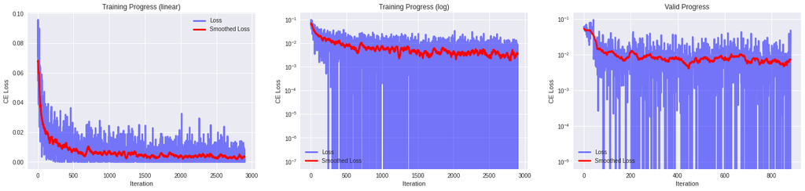

```python
visualize_progress(siamese_resnet_stats['train_loss'], siamese_resnet_stats['valid_loss'])
```

```python
siamese_model = SiameseModel(in_spatial=[250,250])
siamese_optim = torch.optim.Adam(siamese_model.parameters(), lr=9e-5, weight_decay=1e-5)
siamese_ckp_filename = 'ckp_siamese/checkpoint_epoch_19.pt'
siamese_epoch, siamese_stats = load_model(siamese_model, siamese_optim, siamese_ckp_filename)
```

```python
siamese_model = siamese_model.to(device)
```

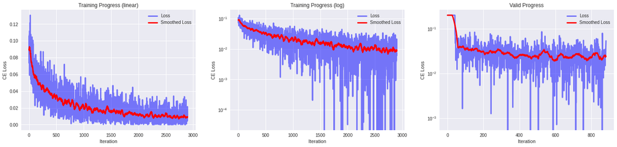

```python
visualize_progress(siamese_stats['train_loss'], siamese_stats['valid_loss'])
```

We can see like in the session, for many iterations, the loss is zero. This is due to the nature of the triplet loss and our naive sample mining strategy.

```python
from sklearn.decomposition import PCA
from sklearn.manifold import TSNE
```

```python
def get_color():
    return np.random.random(), np.random.random(), np.random.random()

def display_projections(points, labels, ax, color_map):
    for l in np.unique(labels):
        idx = np.where(l==labels)
        if len(idx[0]) > 5:  # display only the classes that have more than 5 sample images in the test dataset
            ax.scatter(points[idx, 0], points[idx, 1], c=[color_map[l]])
```

```python
def get_test_emb(model):
    embs = []
    with torch.no_grad():
        for (anchor, _, _), (_,_, _) in test_loader:
            anchor = anchor.to(device)
            anchor_emb = model.forward_one(anchor)
            embs.append(anchor_emb.cpu())
    embs = np.concatenate(embs)
    return embs
```

```python
test_labels = [lbl for (anchor, _, _), (lbl,_, _) in test_loader]
test_labels = np.concatenate(test_labels)
```

```python
color_map = {}
for l in np.unique(test_labels):
    while True:
        color = get_color()
        if color not in color_map.values():
            color_map[l] = color
            break
```

```python
imgs_flat = []
for (anchor, _, _), (_,_, _) in test_loader:
    imgs_flat.append(anchor.cpu().flatten(1))
imgs_flat = np.concatenate(imgs_flat)
pca_imgs = PCA(n_components=2).fit_transform(imgs_flat)
```

```python
siamese_embs = get_test_emb(siamese_model)
siamese_resnet_embs = get_test_emb(siamese_resnet_model)
```

```python
siamese_pca_embs = PCA(n_components=2).fit_transform(siamese_embs)
siamese_resnet_pca_embs = PCA(n_components=2).fit_transform(siamese_resnet_embs)
```

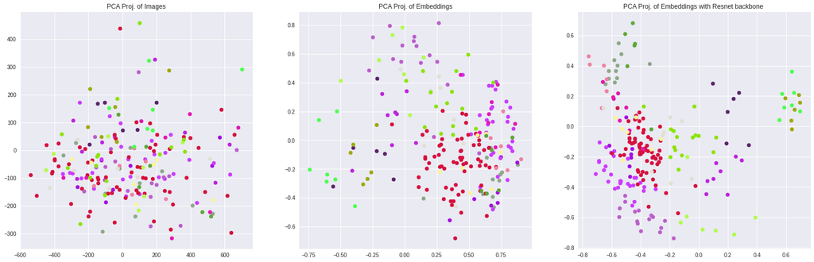

```python
fig,ax = plt.subplots(1,3,figsize=(26,8))
display_projections(pca_imgs, test_labels, ax[0], color_map)
ax[0].set_title("PCA Proj. of Images")
display_projections(siamese_pca_embs, test_labels, ax[1], color_map)
ax[1].set_title("PCA Proj. of Embeddings")
display_projections(siamese_resnet_pca_embs, test_labels, ax[2], color_map)
ax[2].set_title("PCA Proj. of Embeddings with Resnet backbone ")
plt.show()
```

```python
tsne_imgs = TSNE(n_components=2).fit_transform(imgs_flat)
```

```python
siamese_tsne_embs = TSNE(n_components=2).fit_transform(siamese_embs)
siamese_resnet_tsne_embs = TSNE(n_components=2).fit_transform(siamese_resnet_embs)
```

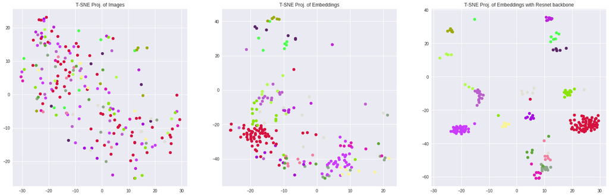

```python
fig,ax = plt.subplots(1,3,figsize=(26,8))
display_projections(tsne_imgs, test_labels, ax[0], color_map)
ax[0].set_title("T-SNE Proj. of Images")
display_projections(siamese_tsne_embs, test_labels, ax[1], color_map)
ax[1].set_title("T-SNE Proj. of Embeddings")
display_projections(siamese_resnet_tsne_embs, test_labels, ax[2], color_map)
ax[2].set_title("T-SNE Proj. of Embeddings with Resnet backbone")
plt.show()
```

```python
from sklearn.cluster import KMeans
from sklearn.metrics import adjusted_rand_score
```

```python
n_clusters = len(np.unique(test_labels))
kmeans_embs = KMeans(n_clusters, random_state=0).fit(siamese_embs)
kmeans_resnet_embs = KMeans(n_clusters, random_state=0).fit(siamese_resnet_embs)
```

```python
ari_embs = adjusted_rand_score(test_labels, kmeans_embs.labels_)
ari_resnet_embs = adjusted_rand_score(test_labels, kmeans_resnet_embs.labels_)
```

```python
print(f"Clustering embeddings achieves ARI={round(ari_embs*100,2)}%")
print(f"Clustering embeddings with resnet backbone achieves ARI={round(ari_resnet_embs*100,2)}%")
```

```
Clustering embeddings achieves ARI=4.88%
Clustering embeddings with resnet backbone achieves ARI=19.06%
```

```python
train_cls = len(np.unique(train_triplet_ds.labels))
val_cls = len(np.unique(val_triplet_ds.labels))
test_cls = len(np.unique(test_triplet_ds.labels))
train_cls, val_cls, test_cls
```

```
(4441, 1737, 932)
```

### Comment

The TriNet Siamese model which has Resnet backbone performs better because the feature extractor is already trained and we are fine-tuning the model in our 20 epochs, while the TriNet Siamese model initialized with random weights needs much more epochs to converge because we are training the whole network from scratch. We can also see this from the graphs from the training and validation processes.

The dataset has 4441 training classes, 1737 validation classes and 932 test classes. This fact might be a reason why the training is not as successful as the training presented on MNIST Fashion dataset which has 10 classes.

Nevertheless, the tools for visualizing the test embeddings (PCA and TSNE) show us that the model has learned the similarity between images from a same class. For making clearer scatter plot, we only show the embeddings from classes that have more than 5 images in the test set.